# Análise Eploratória

Gráficos Exploratórios

Delermando Branquinho Filho

# # Por que usamos gráficos na análise de dados?

- Para entender as propriedades dos dados
- Encontrar padrões nos dados
- Sugerir estratégias de modelagem
- Para “depurar” análises
- Comunicar resultados

## Gráficos exploratórios

- Para entender as propriedades dos dados
- Para encontrar padrões nos dados
- Para sugerir estratégias de modelagem
- Para “depurar” análises
- Comunicar resultados

## Características dos gráficos exploratórios

- Eles são feitos rapidamente
- Um grande número é feito
- O objetivo é a compreensão pessoal
- Eixos / lendas são geralmente limpos (mais tarde)
- Cor / tamanho são usados principalmente para informações

## Poluição do ar nos Estados Unidos

- A Agência de Proteção Ambiental dos Estados Unidos (EPA) normas de qualidade do ar para a poluição do ar

[Nos Padrões Nacionais de Qualidade do Ar Ambiental] (http://www.epa.gov/air/criteria.html)

- Para a poluição por partículas finas (PM2.5), a média anual, 3 anos “não pode exceder $ 12 ~ mu g / m ^ 3 $.
- Os dados sobre as PM2,5 diárias estão disponíveis no site da US EPA - [Sistema de Qualidade do Ar da EPA] (http://www.epa.gov/ttn/airs/airsaqs/detaildata/downloadaqsdata.htm)
- ** Pergunta **: Existe algum município nos EUA que exceda esse padrão nacional para a poluição por partículas finas?

## Dados

Média anual média de PM2,5 no período de 2008 a 2010

```r
pollution <- read.csv("data/avgpm25.csv", colClasses = c("numeric", "character", "factor", "numeric", "numeric"))
head(pollution)
```

```
##        pm25  fips region longitude latitude
## 1  9.771185 01003   east -87.74826 30.59278
## 2  9.993817 01027   east -85.84286 33.26581
## 3 10.688618 01033   east -87.72596 34.73148
## 4 11.337424 01049   east -85.79892 34.45913
## 5 12.119764 01055   east -86.03212 34.01860
## 6 10.827805 01069   east -85.35039 31.18973
```

Algum condado excede o padrão de $ 12 ~ mu g / m ^ 3 $?

## Resumos Simples de Dados

Uma dimensão

- Resumo de cinco números
- Boxplots
- Histogramas
- Density plot
- Barplot

## Resumo de cinco números

```r
summary(pollution$pm25)
```

```
##    Min. 1st Qu.  Median    Mean 3rd Qu.    Max.
##   3.383   8.549  10.047   9.836  11.356  18.441
```

## Boxplot

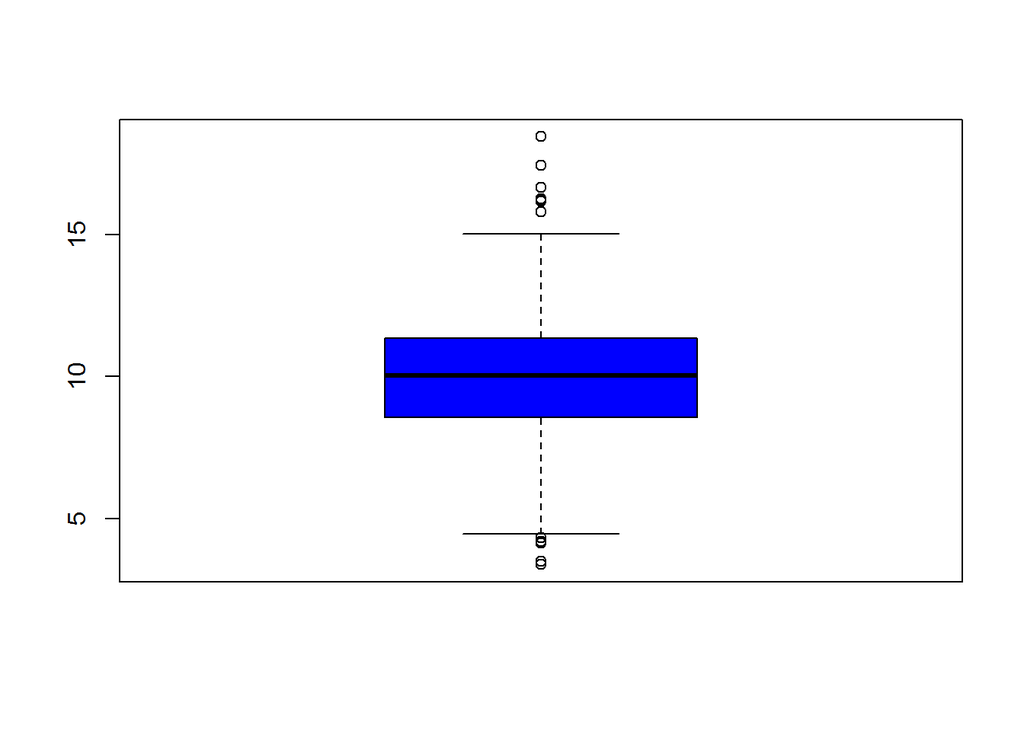

```r
boxplot(pollution$pm25, col = "blue")
```

## Histogram

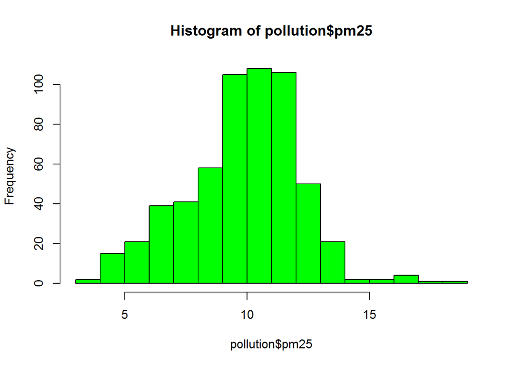

```r
hist(pollution$pm25, col = "green")
```

## Histogram

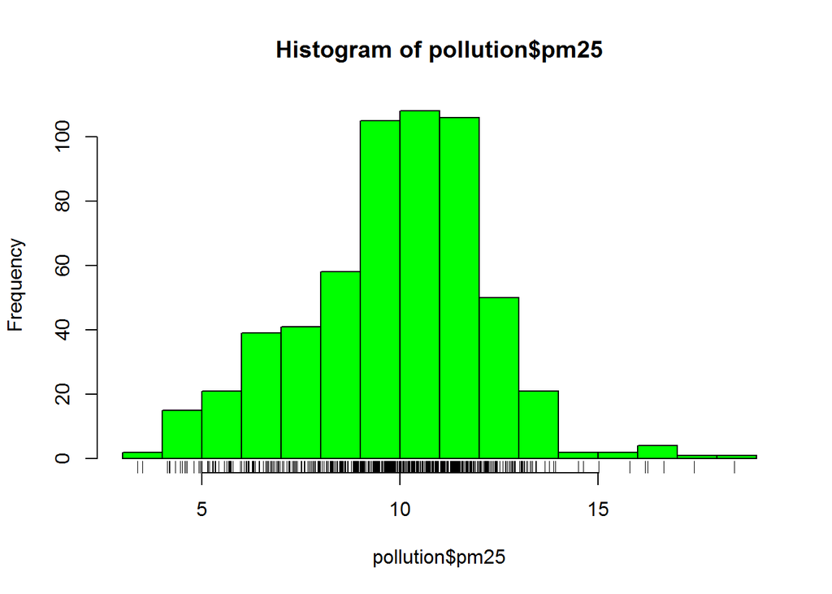

```r
hist(pollution$pm25, col = "green")
rug(pollution$pm25)
```

## Histogram

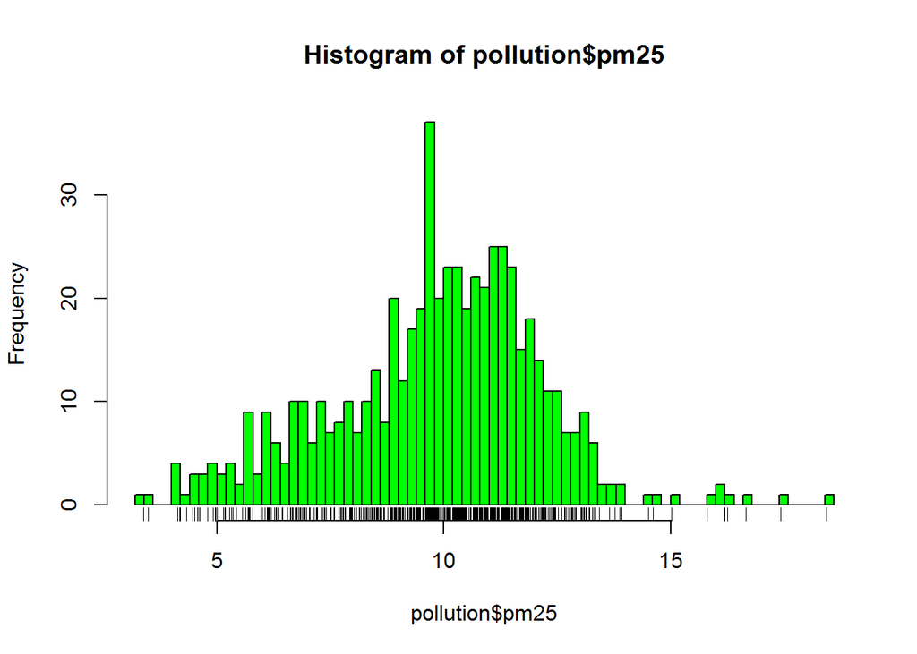

```r
hist(pollution$pm25, col = "green", breaks = 100)
rug(pollution$pm25)
```

## Sobreposição de recursos

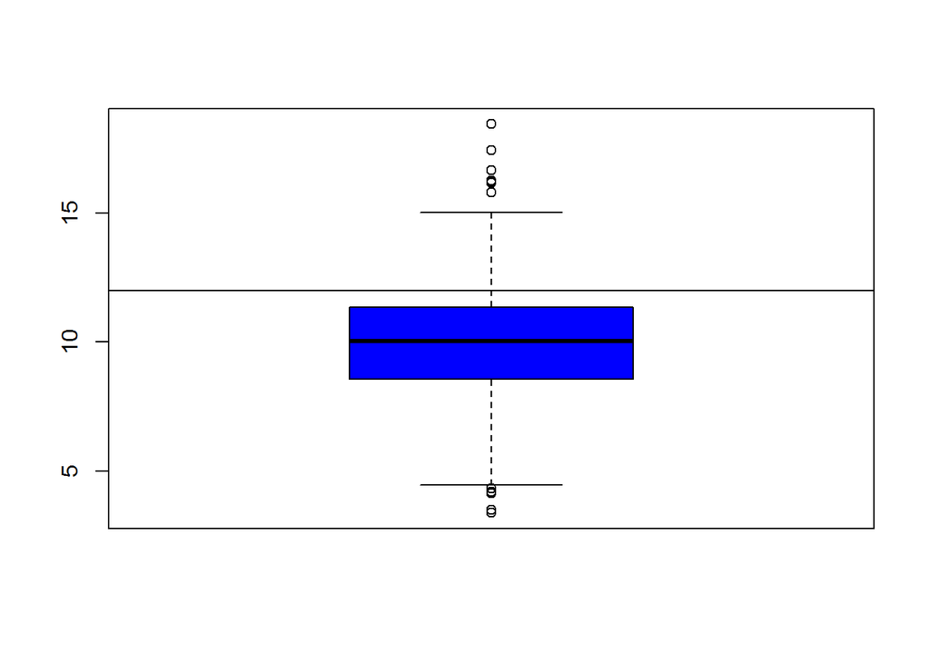

```r
boxplot(pollution$pm25, col = "blue")
abline(h = 12)
```

## Sobreposição de recursos

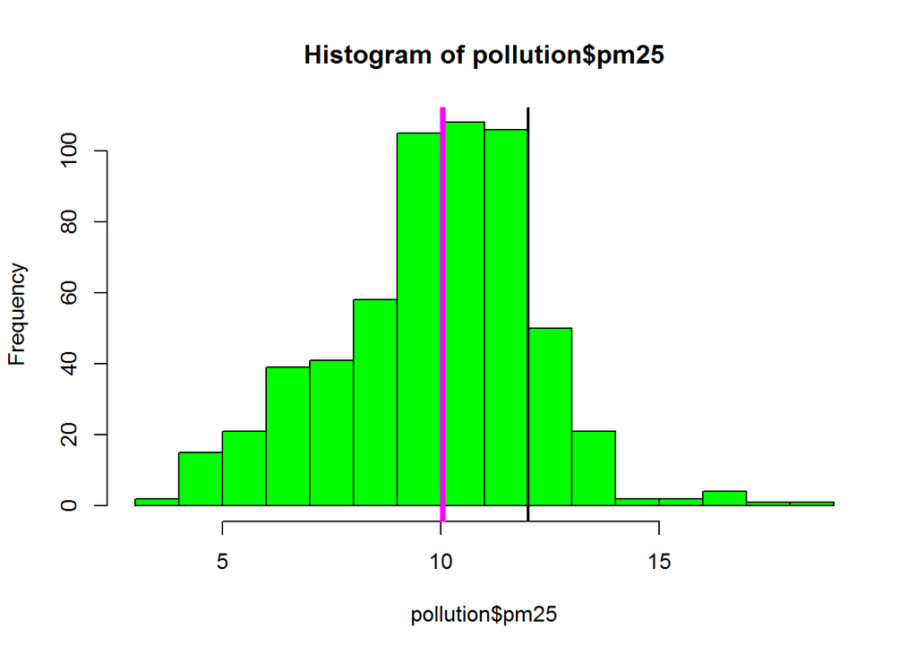

```r
hist(pollution$pm25, col = "green")
abline(v = 12, lwd = 2)
abline(v = median(pollution$pm25), col = "magenta", lwd = 4)
```

## Barplot

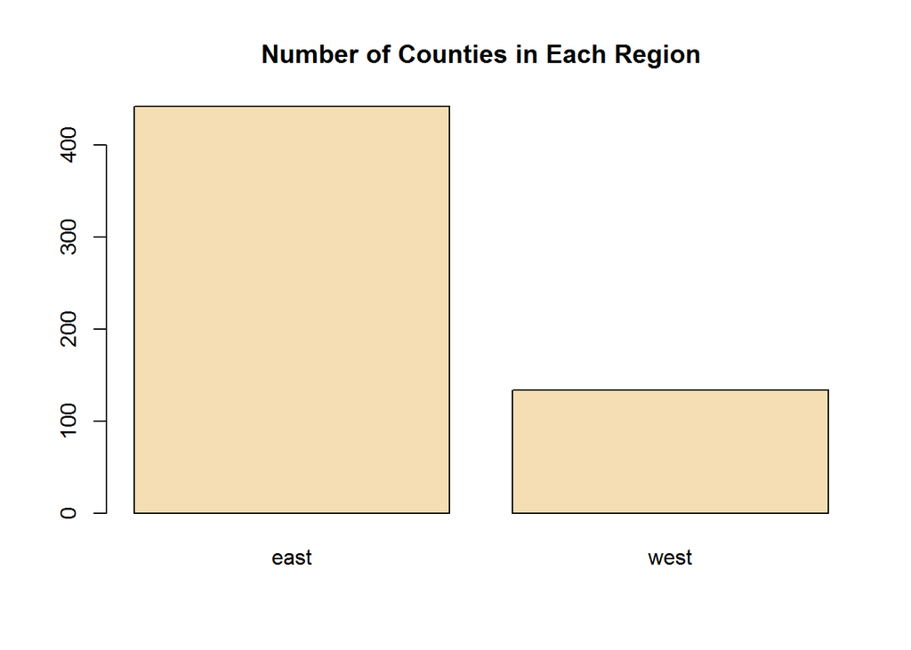

```r
barplot(table(pollution$region), col = "wheat", main = "Number of Counties in Each Region")
```

## Resumos Simples de Dados

Duas dimensões

- Múltiplos / sobrepostos parcelas 1-D (Lattice / ggplot2)
- Scatterplots
- Liso scatterplots

$> 2 $ dimensões

- Overlayed / múltiplas parcelas 2-D; Coplotes
- Use cor, tamanho, forma para adicionar dimensões
- Spinning plots
- Real 3-D parcelas (não é útil)

## Multiplos Boxplots

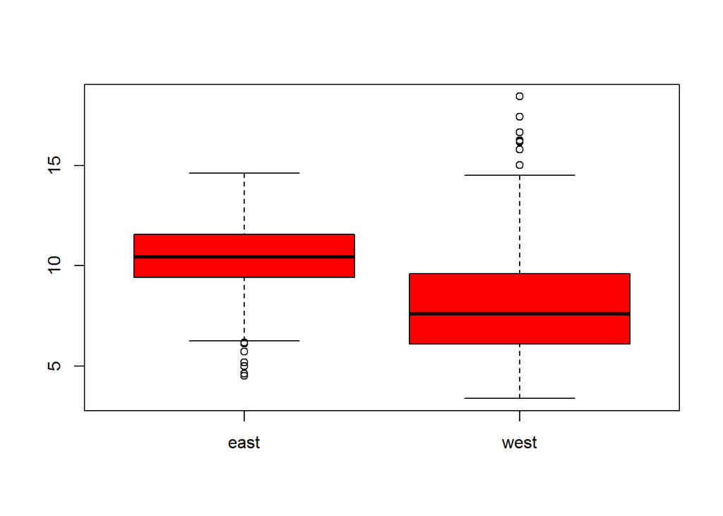

```r
boxplot(pm25 ~ region, data = pollution, col = "red")
```

## Multiplos Histograms

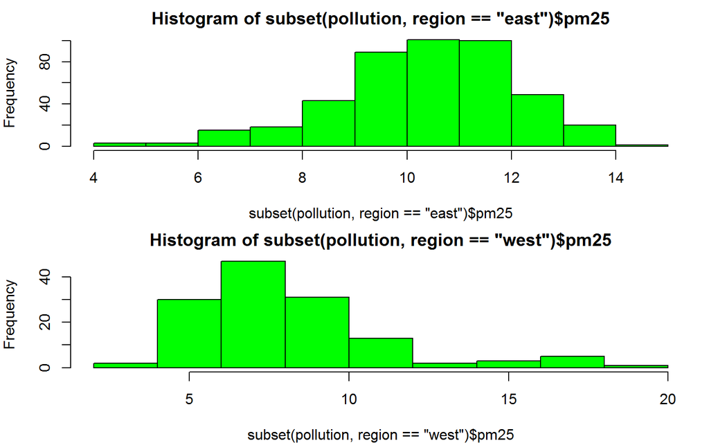

```r
par(mfrow = c(2, 1), mar = c(4, 4, 2, 1))
hist(subset(pollution, region == "east")$pm25, col = "green")
hist(subset(pollution, region == "west")$pm25, col = "green")
```

## Dispersão

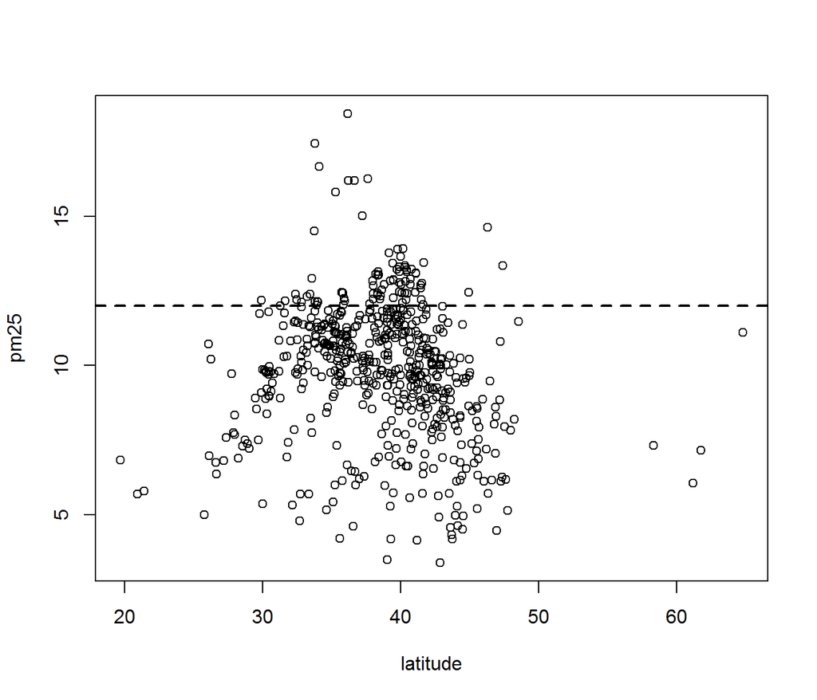

```r
with(pollution, plot(latitude, pm25))
abline(h = 12, lwd = 2, lty = 2)
```

## Dispersão - Usindo Color

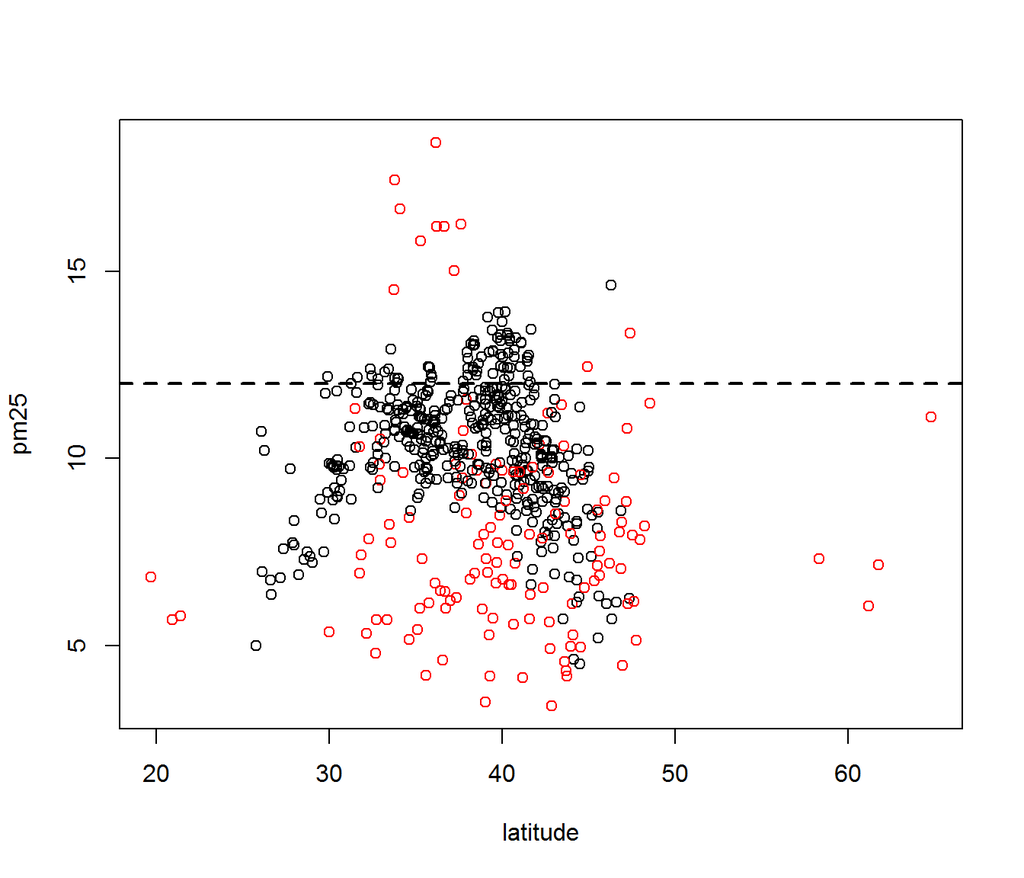

```r
with(pollution, plot(latitude, pm25, col = region))
abline(h = 12, lwd = 2, lty = 2)
```

## Dispersão Multipla

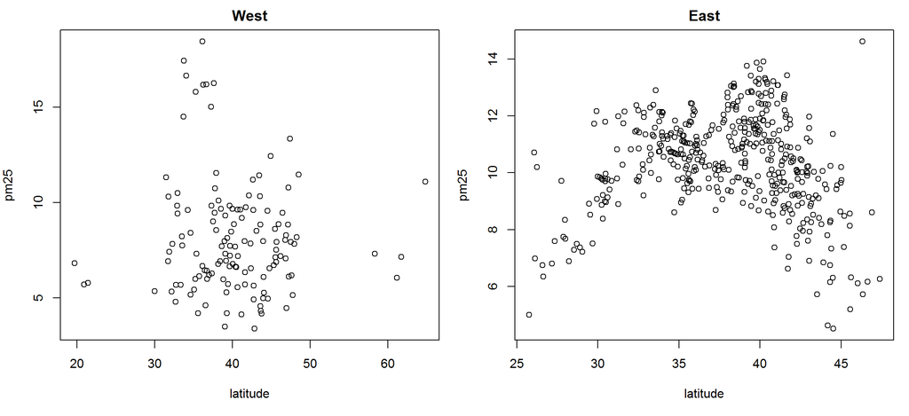

```r
par(mfrow = c(1, 2), mar = c(5, 4, 2, 1))
with(subset(pollution, region == "west"), plot(latitude, pm25, main = "West"))
with(subset(pollution, region == "east"), plot(latitude, pm25, main = "East"))
```

## Outros recursos

- [R Graph Gallery] (http://gallery.r-enthusiasts.com/)
- [R Bloggers] (http://www.r-bloggers.com/)